# Time Series Homework: Chapter 3 Lesson 5

Tristan Farrow

## Data

```r
ngdp <- rio::import("https://byuistats.github.io/timeseries/data/gdp_fred.csv")
rgdp <- rio::import("https://byuistats.github.io/timeseries/data/GDPC1.csv")
```

## Questions

### Question 1 - Context and Measurement (10 points)

The first part of any time series analysis is context. You cannot properly analyze data without knowing what the data is measuring. Without context, the most simple features of data can be obscure and inscrutable. This homework assignment will center around the series below.

Please research the time series. In the spaces below, give the data collection process, unit of analysis, and meaning of each observation for the series.

**Nominal Gross Domestic Product - United States**

https://fred.stlouisfed.org/series/NA000334Q

**Answer**

Data Collection Process: Gross Domestic Product (GDP) is broken down into a few different parts: consumer spending, business investment, government spending, and net exports. These different sectors can be fit together to make the GDP formula, Nominal GDP $= C+I+G+(X-M)$. This data originates from the National Income and Product Accounts (NIPA) which capture the market value of the goods and services produced by labor and property located in the United States.

Unit of Analysis: The unit of analysis is everything a country produces during a certain period at current prices on a national level.

Meaning of Observation: Each observation represents the total market value of goods and services produced at current prices.

**Real Gross Domestic Product - United States**

https://fred.stlouisfed.org/series/GDPC1

**Answer**

Data Collection Process: Real GDP is the nominal GDP after being adjusted for inflation using a price index.

Unit of Analysis: The unit of analysis is everything a country produces during a certain period on a national level using 2017 as a base year.

Meaning of Observation: Each observation represents the value of production adjusted for price changes. The price adjustment help to remove the price change distortion to capture the more realistic idea of national production.

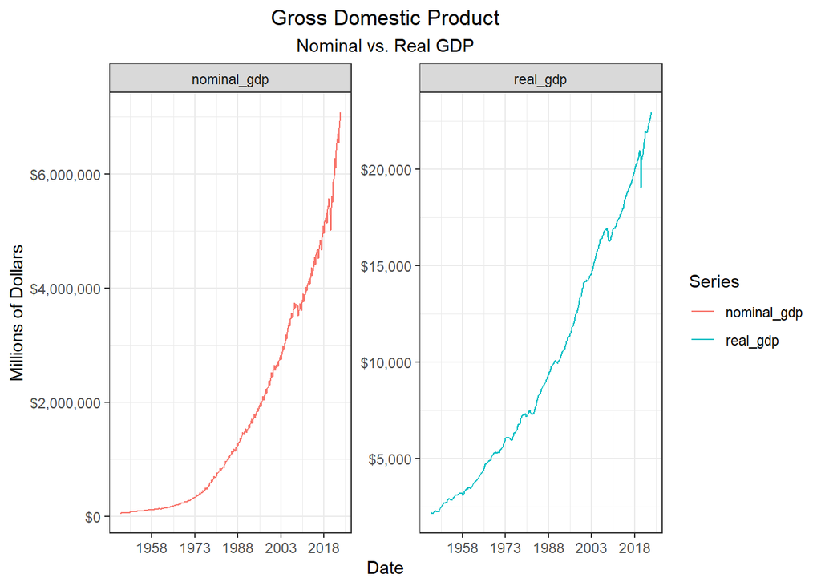

```r
ngdp_ts <- ngdp |>
  mutate(quarter = yearquarter(quarter)) |>
  rename("nominal_gdp" = gdp_millions) |>
  select(quarter, nominal_gdp) |>
  tsibble(index = quarter)

rgdp_ts <- rgdp |>
  mutate(quarter = yearquarter(DATE)) |>
  rename("real_gdp" = GDPC1) |>
  select(quarter, real_gdp) |>
  tsibble(index = quarter)

data <- left_join(ngdp_ts, rgdp_ts, by = "quarter") |>
  pivot_longer(
    cols = c(nominal_gdp, real_gdp),
    names_to = "Series",
    values_to = "Values"
  )

ggplot(data = data, aes(x = as.Date(quarter), y = Values, color = Series)) +
  geom_line() +
  labs(
    title = "Gross Domestic Product",
    subtitle = "Nominal vs. Real GDP",
    x = "Date",
    y = "Millions of Dollars"
  ) +
  scale_y_continuous(
    labels = scales::label_dollar()
  ) +
  scale_x_date(
    breaks = "15 years",
    labels = scales::date_format("%Y")
  ) +
  facet_wrap(~ Series, scales = "free_y") +
  theme_bw() +
  theme(
    plot.title = element_text(hjust = 0.5),
    plot.subtitle = element_text(hjust = 0.5)
  )
```

### Question 2 - US Nominal GDP (25 points)

#### a) Please use the Holt-Winters smoothing method to the US Nominal GDP series. Justify your model choice.

**Answer**

```r
nominal_hw <- ngdp_ts |>
  model(Additive = ETS(nominal_gdp ~ trend("A", alpha = 0.1, beta = 0.01) + error("A") + season("M", gamma = 0.05),
        opt_crit = "amse", nmse = 1))

report(nominal_hw)
```

```
Series: nominal_gdp
Model: ETS(A,A,M)
  Smoothing parameters:
    alpha = 0.1
    beta  = 0.01
    gamma = 0.05

  Initial states:
     l[0]     b[0]      s[0]   s[-1]   s[-2]     s[-3]
 60229.17 1385.527 0.9491695 1.07778 0.98605 0.9870001

  sigma^2:  8583995252

     AIC     AICc      BIC
8813.700 8813.979 8836.081
```

I selected an additive model with multiplicative seasonality because, as the trend increases, the cyclical fluctuations in the data also grow in magnitude. A purely additive model would fail to capture this expanding seasonal variation, causing those effects to be absorbed into the error term instead of being modeled appropriately.

#### b) What parameters values did you choose for $\alpha$, $\beta$, and $\gamma$. Justify your choice.

**Answer**

$Alpha$: 0.1 $Beta$: 0.01 $Gamma$:0.05

#### c) Please plot the Holt-Winters forecast of the series for the next 12 months superimposed against the original series. Please see [Figure 7](https://byuistats.github.io/timeseries/chapter_3_lesson_3.html#fig-crime-hw-forecast) in Chapter 3: Lesson 3.

**Answer**

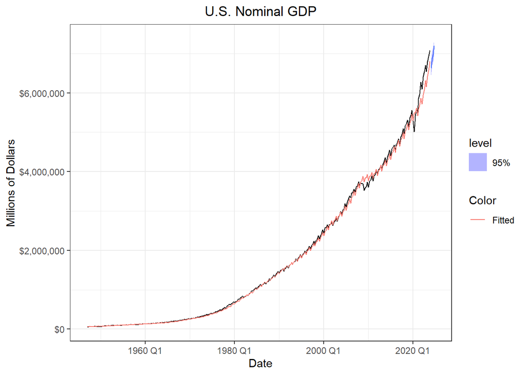

```r
nominal_forecast <- nominal_hw |>
  forecast(h = "12 months")

nominal_forecast |>
  autoplot(ngdp_ts, level = 95) +
  geom_line(aes(y = .fitted, color = "Fitted"),
            data = augment(nominal_hw)) +
  labs(
    title = "U.S. Nominal GDP",
    x = "Date",
    y = "Millions of Dollars",
    color = "Color"
  ) +
  scale_y_continuous(labels = scales::label_dollar())+
  theme_bw() +
  theme(
    plot.title = element_text(hjust = 0.5)
  )
```

#### d) How confident are you in your forecast? Please explain.

Obviously, caution needs to be taken with any forecast as it is just that, a forecast. Forecasts are assuming that past trends continue but there is no guarantee that will happen.

### Question 3 - US Real GDP (25 points)

Nominal GDP measures the market value of US output. Because market prices change over time, inflation affects the series. Real GDP is an output measure that keeps prices constant at a point in time, which eliminates the effect of inflation.

In homework 2.1 you learned about the output gap, which is a measure of business cycles. In order to estimate the output gap we need some measure of potential GDP, that is, a series that smoothes-out the cycles in the real GDP series. We can do that by choosing the smoothing parameters of the H-W algorithm to capture only the long run path of the economy. The US Congressional Budget Office calculates a series for [US Real Potential GDP](https://fred.stlouisfed.org/series/GDPPOT), please refer to it for the questions that follow.

#### a) Please use H-W to smooth the US Real GDP series to obtain an estimate of US Potential GDP.

**Answer**

```r
real_hw <- rgdp_ts |>
  model(Additive = ETS(real_gdp ~
        trend("A", alpha = 0.1, beta = 0.05) + error("A") + season("M", gamma = 0.001),
        opt_crit = "amse", nmse = 1))

report(real_hw)
```

```
Series: real_gdp
Model: ETS(A,A,M)
  Smoothing parameters:
    alpha = 0.1
    beta  = 0.05
    gamma = 0.001

  Initial states:
    l[0]     b[0]    s[0]    s[-1]     s[-2]     s[-3]
 2071.39 4.471025 1.00174 1.000942 0.9973638 0.9999546

  sigma^2:  82706.4

     AIC     AICc      BIC
5292.379 5292.656 5314.798
```

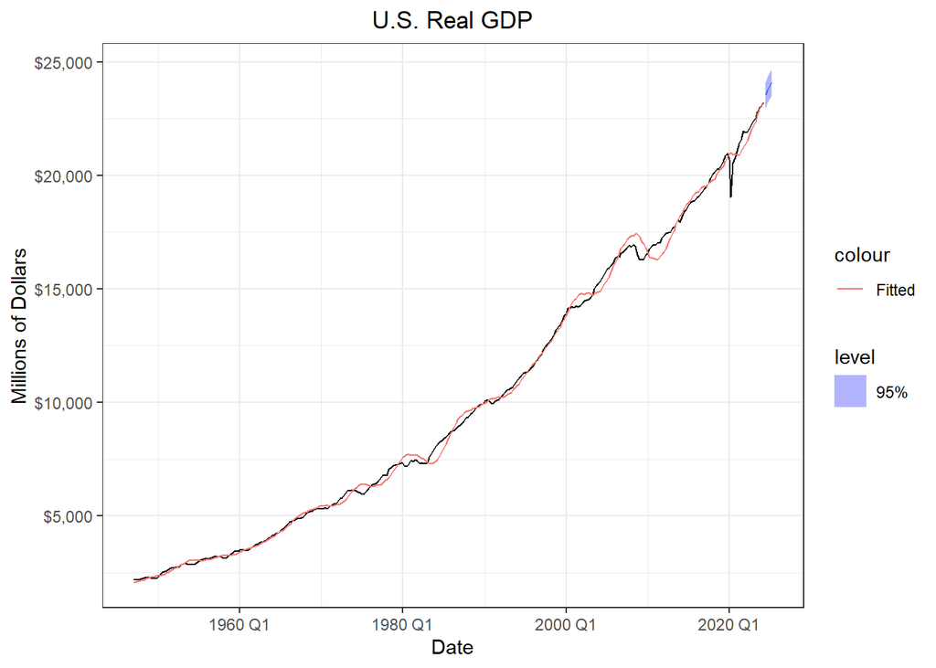

```r
real_forecast <- real_hw |>
  forecast(h = "12 months")

real_forecast |>
  autoplot(rgdp_ts, level = 95) +
  geom_line(aes(y = .fitted, color = "Fitted"),
            data = augment(real_hw)) +
  labs(
    title = "U.S. Real GDP",
    x = "Date",
    y = "Millions of Dollars"
  ) +
  scale_y_continuous(
    labels = scales::label_dollar()
  ) +
  theme_bw() +
  theme(
    plot.title = element_text(hjust = 0.5)
  )
```

#### b) What parameters values did you choose for $\alpha$, $\beta$, and $\gamma$. Justify your choice.

**Answer**

$Alpha$: 0.1 $Beta$: 0.05 $Gamma$: 0.001

### Rubric

[output not shown]